# Data 621 Blog 1

Outliers

Author

Darwhin Gomez

## Three Visual methods for identifying Outliers

In statistical analysis and modeling, the primary goal is to understand a dataset in order to gain insights and, in many cases, make predictions based on the information it contains. However, as one explores data more deeply, it often becomes apparent that some observations differ substantially from the rest. These observations are known as **outliers**.

An outlier is a data point that deviates markedly from other records in a dataset, either by being unusually large or unusually small relative to the majority of observations ([GeeksforGeeks](https://www.geeksforgeeks.org/maths/outlier/)). Outliers can arise for many reasons, including data entry errors, measurement issues, or genuine but rare events. Because of their extreme nature, outliers deserve careful attention during the modeling process.

### Box Plot

Several statistical methods exist for detecting outliers, and one of the most accessible tools available in R is the **box plot**. A box plot summarizes a continuous variable by displaying its median and interquartile range (IQR), which represents the middle 50% of the data. The “whiskers” extend to observations within 1.5 times the IQR from the first and third quartiles. Any data points that fall beyond these limits are flagged as potential outliers.

Box plots provide a quick and intuitive visualization that helps analysts identify extreme values early in the exploratory data analysis process. This makes them especially useful for diagnosing potential issues in the data before fitting statistical models or drawing conclusions.

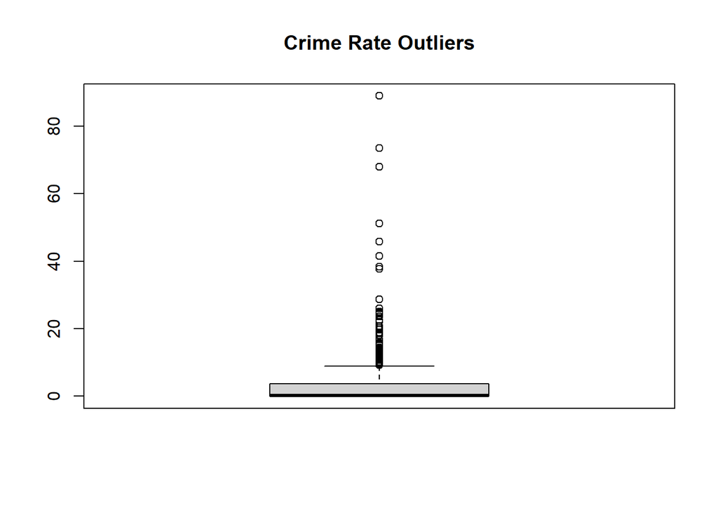

```r
bos_crime_op<-boxplot(Boston$crim, main = "Crime Rate Outliers")
```

### Density Plot

A density plot or histogram can also be helpful in visualizing outliers in data and is fairly simple to create using imposed interquartile range thresholds. By overlaying cutoff lines or shading extreme values, these plots make it easier to see how potential outliers relate to the overall shape and tails of the distribution, providing additional context beyond summary statistics alone.

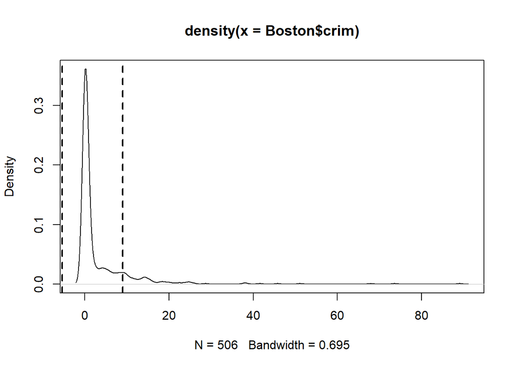

```r
x <- Boston$crim

# Compute IQR thresholds
Q1 <- quantile(x, 0.25)
Q3 <- quantile(x, 0.75)
IQR <- Q3 - Q1

lower_bound <- Q1 - 1.5 * IQR
upper_bound <- Q3 + 1.5 * IQR

# Histogram of full distribution
plot(density(
  Boston$crim,
))

# Add cutoff lines
abline(v = lower_bound, lwd = 2, lty = 2)
abline(v = upper_bound, lwd = 2, lty = 2)
```

```r
# Overlay shaded outliers
```

[output not shown]

### Q-Q Plot

Finally, another simple method for detecting outliers is the Q–Q plot, which compares the quantiles of the observed data to those of a theoretical distribution (typically normal). Observations that deviate substantially from the reference line particularly in the tails should be examined as potential outliers.

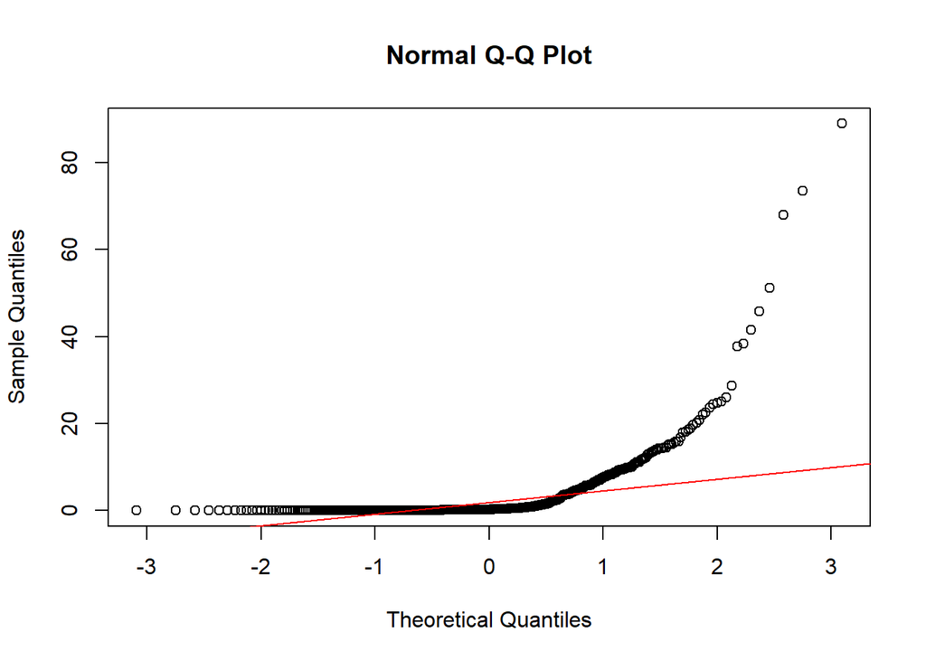

```r
qqnorm(Boston$crim)
qqline(Boston$crim, col= "red")
```

### Anomolies

It is important to recognize that in some analyses, we actively seek extreme outliers particularly in cases where we want to identify observations that break established patterns in a significant way. A common example of this is fraud detection, where anomalous transactions may indicate suspicious or fraudulent behavior. In such contexts, anomaly detection techniques are used to flag observations that deviate sharply from expected patterns rather than treating them as noise to be removed.

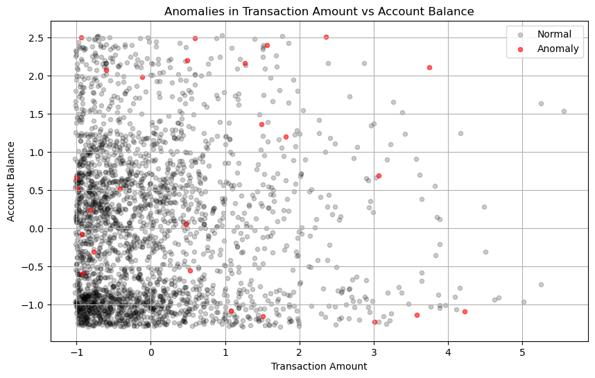

[Link to notebook](https://github.com/DW8888/Data602/blob/main/Bank%20Transaction%20Fraud/isolationf_anomoly_detection.ipynb)

### Final thoughts

Outliers can be detected simple visualizations, like using box plots, histograms or density plots, and Q–Q plots, each offering a simple visual perspective on extreme observations. Box plots use interquartile range thresholds, while distribution plots and Q–Q plots reveal how outliers appear in the tails of the data. These methods help assess data quality and modeling assumptions.

In some applications, such as fraud or anomaly detection, extreme outliers are not noise but the primary signals of interest.